# Carly Davenport + Erik Van: Final_Project

Carly Davenport, Erik Van

12/10/2021

# CEE 218X Final Project

## Key questions:

### What is the relationship between poverty, race, covid rates, and covid testing rates? How do only comparing two of these variables versus all three together change the trend/relationship we see?

#### What is the relationship between race, covid rates, and covid testing rates? How do only comparing two of these variables versus all three together change the trend/relationship we see?

#### Geographically, how does covid rates and testing map across the city of Oakland? What key insights can be drawn from this mapping?

### General Notes for soft submission: We worked on pulling and formatting the data we needed for our project and made some preliminary graphs (though we plan to include more + analysis of results). Realizing that our covid data is in terms of zipcodes and our other census data is in terms of census tracts, we will have to stick to just using some side-by-side analysis to draw certain conclusion, but we still hope that the results can be informative (and ideally in a convenient dashboard format)

## Map area of interest (county level): Alameda County

[interactive chart not shown]

## Map area of interest (city level): Oakland

[interactive chart not shown]

## Map of Oakland by zipcode

### NOTE: Oakland shares some zipcodes with other cities, which don’t seem to be included

[interactive chart not shown]

## COVID Cases and Testing in Oakland

### COVID Dataset from Alameda County COVID-19 Case/Case Rates by Zip Code GeoJSON API URL:

### “https://opendata.arcgis.com/datasets/5d6bf4760af64db48b6d053e7569a47b_0.geojson”

### COVID Dataset from Alameda County COVID-19 Test Rates by Zip Code GeoJSON API URL:

### “https://opendata.arcgis.com/datasets/5d6bf4760af64db48b6d053e7569a47b_4.geojson”

### Filter covid data to oakland zip codes

## Map of Covid Test Rates in Oakland

[interactive chart not shown]

## Map of Covid Case Rates in Oakland

[interactive chart not shown]

## Using census data to map income and race in Oakland

### Filter to the tracts that belong to Oakland

## Equity analysis of income and race in Oakland

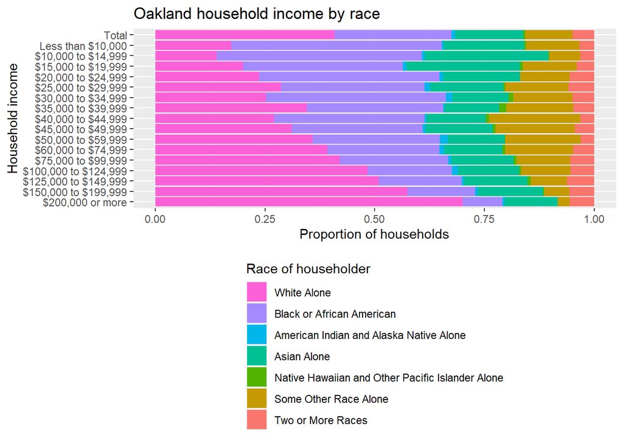

### Assumptions about above graph:

### My first major assumption is that the breakdown of race in this visual is representative of the breakdown of population in Oakland. Another assumption is the validity, completeness, and accuracy of the data set used. This data set is gathered and produced by the US Census, so we are assuming it is from a credible source on the topic and was gathered in a fair and unbiased way.

## Example of plotting Black population in Oakland

### Breakdown of African American population in Oakland

[interactive chart not shown]

## Example of plotting White population in Oakland

### Breakdown of White population in Oakland

[interactive chart not shown]

## Example of plotting lowest income population in Oakland

### Breakdown of lowest income population in Oakland

[interactive chart not shown]

## Example of plotting highest income population in Oakland

### Breakdown of highest income population in Oakland

[interactive chart not shown]

## Findings based on the above maps:

### These preliminary findings are only looking at the highest/lowest income population as well only as white and black people. The population of Oakland is a lot more diverse than that so further investigation is needed.

## Regression Modeling

### Covid cases versus testing

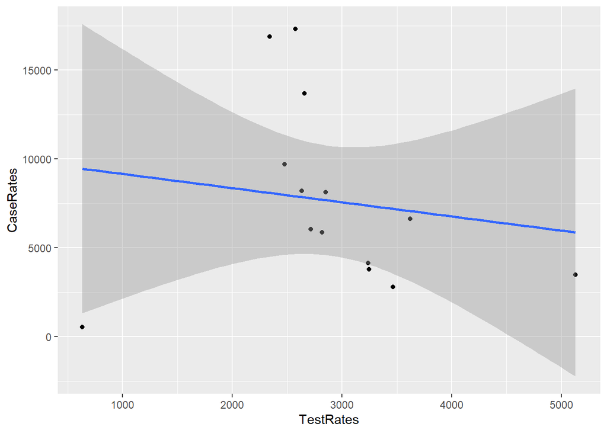

```
##
## Call:
## lm(formula = CaseRates ~ TestRates, data = covidData_oakland)
##
## Residuals:
##    Min     1Q Median     3Q    Max
##  -8913  -3030  -1097   1405   9418
##
## Coefficients:
##              Estimate Std. Error t value Pr(>|t|)
## (Intercept) 9963.9011  4647.7817   2.144   0.0532 .
## TestRates     -0.7976     1.5339  -0.520   0.6125
## ---
## Signif. codes:  0 '***' 0.001 '**' 0.01 '*' 0.05 '.' 0.1 ' ' 1
##
## Residual standard error: 5303 on 12 degrees of freedom
## Multiple R-squared:  0.02204,    Adjusted R-squared:  -0.05946
## F-statistic: 0.2704 on 1 and 12 DF,  p-value: 0.6125
```

### The model shows based on the p-value that the results are not very usable and accurate, which could also be due to having limited availability (have as many data points as there are zipcodes in Oakland)